# 벡터와 행렬 다루기, 수치해석

seokohj@hufs.ac.kr

```r
set.seed(0)   # 재현성을 위해...
```

# 행렬 다루기

## 전치행렬

행렬 $A = (a_{ij})$의 **전치행렬(transpose)** $A^\top = (a_{ji})$은 R 함수 `t()`를 이용하면 간단히 구할 수 있다.

```r
print(A <- round(matrix(rnorm(12), 4, 3), 2))
```

```
##       [,1]  [,2]  [,3]
## [1,]  1.26  0.41 -0.01
## [2,] -0.33 -1.54  2.40
## [3,]  1.33 -0.93  0.76
## [4,]  1.27 -0.29 -0.80
```

```r
t(A)
```

```
##       [,1]  [,2]  [,3]  [,4]
## [1,]  1.26 -0.33  1.33  1.27
## [2,]  0.41 -1.54 -0.93 -0.29
## [3,] -0.01  2.40  0.76 -0.80
```

## 벡터의 내적과 외적

두 벡터 $\boldsymbol{x}$와 $\boldsymbol{y}$에 대해 계산한 $\boldsymbol{x}^\top \boldsymbol{y}$를 **내적(inner product)**이라 하고, $\boldsymbol{x}\boldsymbol{y}^\top$를 **외적(outer product)**이라 한다. 외적은 R 함수 `outer()` 또는 `%o%`를 사용해 계산한다.

```r
x <- 1:3
y <- 4:6
```

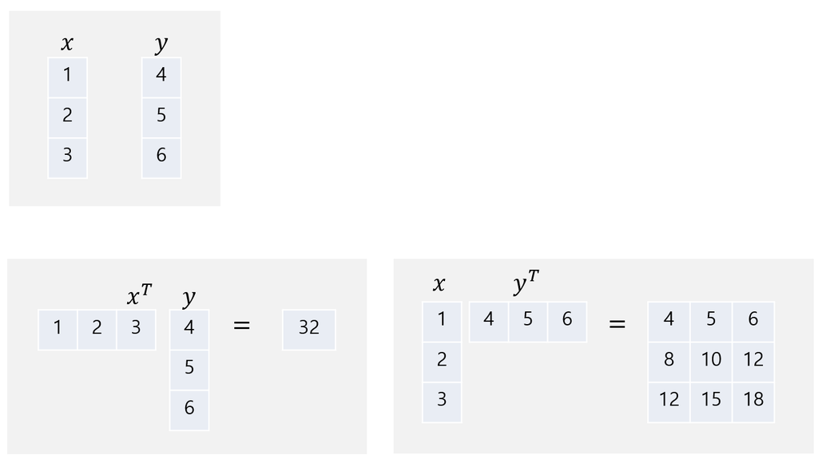

```r
sum(x * y)  # inner product
```

```
## [1] 32
```

```r
t(x) %*% y
```

```
##      [,1]
## [1,]   32
```

```r
drop(t(x) %*% y)
```

```
## [1] 32
```

```r
outer(x, y) # outer product
```

```
##      [,1] [,2] [,3]
## [1,]    4    5    6
## [2,]    8   10   12
## [3,]   12   15   18
```

```r
x %o% y
```

```
##      [,1] [,2] [,3]
## [1,]    4    5    6
## [2,]    8   10   12
## [3,]   12   15   18
```

```r
x %*% t(y)
```

```
##      [,1] [,2] [,3]
## [1,]    4    5    6
## [2,]    8   10   12
## [3,]   12   15   18
```

### `outer()`의 확장 활용

```r
outer(x, y, FUN = "*")
```

```
##      [,1] [,2] [,3]
## [1,]    4    5    6
## [2,]    8   10   12
## [3,]   12   15   18
```

```r
outer(x, y, FUN = "+")
```

```
##      [,1] [,2] [,3]
## [1,]    5    6    7
## [2,]    6    7    8
## [3,]    7    8    9
```

$f(x, y) = \frac{\sin\sqrt{x^2 + y^2}}{\sqrt{x^2 + y^2}}$의 그래프 그리기:

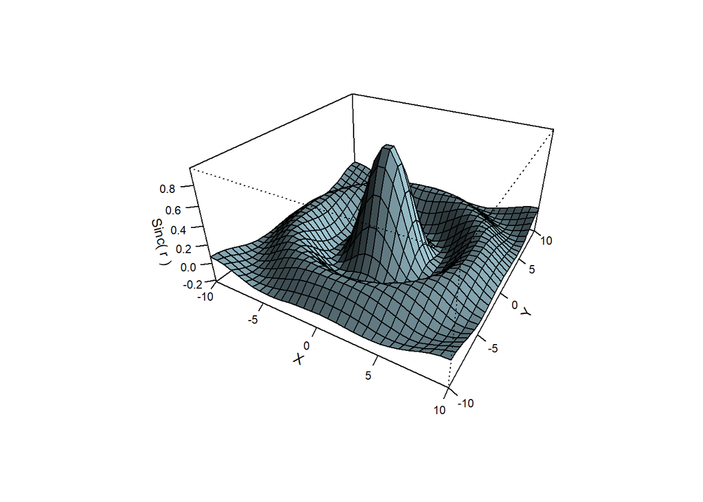

```r
x <- seq(-10, 10, length = 30)
y <- x
f <- function(x, y)
{
  r <- sqrt(x^2 + y^2)
  return(sin(r)/r)
}
z <- outer(x, y, f)
z[is.na(z)] <- 1
persp(x, y, z, theta = 30, phi = 30, expand = 0.5, col = "lightblue",
      ltheta = 120, shade = 0.75, ticktype = "detailed",
      xlab = "X", ylab = "Y", zlab = "Sinc( r )",
      cex.lab = 0.8, cex.axis = 0.7)
```

## 반복 실행

다음은 정규난수로 구성된 $10\times 5$ 행렬을 생성하는 R 코드이다.

```r
N <- 10
d <- 5
X <- round(matrix(rnorm(N*d), N, d), 2)
X
```

```
##        [,1]  [,2]  [,3]  [,4]  [,5]
##  [1,] -1.15  0.13 -0.43 -0.45  2.44
##  [2,] -0.29  0.80 -0.65 -0.83 -0.80
##  [3,] -0.30 -0.06  0.73 -1.17 -0.05
##  [4,] -0.41  0.50  1.15 -1.07  0.25
##  [5,]  0.25  1.09  0.99 -1.56  0.62
##  [6,] -0.89 -0.69 -0.43  1.16 -0.17
##  [7,]  0.44 -1.28  1.24  0.83 -2.22
##  [8,] -1.24  0.05 -0.28 -0.23 -1.26
##  [9,] -0.22 -0.24  1.76  0.27  0.36
## [10,]  0.38 -0.54  0.56 -0.38 -0.01
```

[figure not shown]

```r
# Use image() to visualize a matrix.
# Need to transpose the matrix and then flip it horizontally.
image(t(X)[,N:1], axes = FALSE, col = gray.colors(128))
```

함수 `apply()`는 행렬 형태의 데이터에 대해 행 방향 또는 열 방향으로 지정한 함수를 반복 적용해 준다.

```r
apply(X = X, MARGIN = 1, FUN = mean) # 행 방향으로 평균 계산 반복 실행
```

```
##  [1]  0.108 -0.354 -0.170  0.084  0.278 -0.204 -0.198 -0.592  0.386  0.002
```

```r
apply(X, 2, mean) # 열 빙향으로 평균 계산 반복 실행
```

```
## [1] -0.343 -0.024  0.464 -0.343 -0.084
```

행별 또는 열별 평균 또는 합을 계산할 때에는 `colSums()`, `rowSums()`, `colMeans()`, `rowMeans()` 함수를 이용하면 보다 편리하다. 무엇보다 `apply()`나 루프를 사용하는 것보다 훨씬 빠른 속도로 계산을 마칠 수 있다는 장점이 있다.

```r
# for ( n in 1:N ) mean(X[n,])  # Not run...
# apply(X, 1, mean) # Not run...
head(rowMeans(X))
```

```
## [1]  0.108 -0.354 -0.170  0.084  0.278 -0.204
```

```r
head(colMeans(X))
```

```
## [1] -0.343 -0.024  0.464 -0.343 -0.084
```

```r
head(rowSums(X))
```

```
## [1]  0.54 -1.77 -0.85  0.42  1.39 -1.02
```

```r
head(colSums(X))
```

```
## [1] -3.43 -0.24  4.64 -3.43 -0.84
```

`scale()` 함수는 행렬 또는 데이터프레임 형태로 주어진 데이터의 각 열에 대해 **표준화** 변환
$$z = (x - {\bar x})/s$$
을 수행해준다.

```r
Z <- scale(X) # scale(X, center = TRUE, scale = TRUE)
head(Z)
```

```
##             [,1]        [,2]       [,3]       [,4]        [,5]
## [1,] -1.33946957  0.21637410 -1.0518019 -0.1216135  2.04970506
## [2,]  0.08797012  1.15774194 -1.3106346 -0.5535119 -0.58145357
## [3,]  0.07137198 -0.05058096  0.3129522 -0.9399474  0.02761092
## [4,] -0.11120751  0.73623395  0.8070874 -0.8262899  0.27123672
## [5,]  0.98426946  1.56519966  0.6188454 -1.3832116  0.57170854
## [6,] -0.90791803 -0.93574773 -1.0518019  1.7082720 -0.06983940
```

```r
print(R <- cov(Z))
```

```
##            [,1]       [,2]        [,3]        [,4]       [,5]
## [1,]  1.0000000 -0.1403965  0.63631042 -0.12668702 -0.3206112
## [2,] -0.1403965  1.0000000 -0.16227989 -0.83464157  0.4152919
## [3,]  0.6363104 -0.1622799  1.00000000 -0.06645558 -0.1033498
## [4,] -0.1266870 -0.8346416 -0.06645558  1.00000000 -0.3637960
## [5,] -0.3206112  0.4152919 -0.10334983 -0.36379600  1.0000000
```

```r
cor(X)  # should be equal to R
```

```
##            [,1]       [,2]        [,3]        [,4]       [,5]
## [1,]  1.0000000 -0.1403965  0.63631042 -0.12668702 -0.3206112
## [2,] -0.1403965  1.0000000 -0.16227989 -0.83464157  0.4152919
## [3,]  0.6363104 -0.1622799  1.00000000 -0.06645558 -0.1033498
## [4,] -0.1266870 -0.8346416 -0.06645558  1.00000000 -0.3637960
## [5,] -0.3206112  0.4152919 -0.10334983 -0.36379600  1.0000000
```

## 행렬곱

두 행렬 $A$, $B$의 **행렬곱(matrix multiplication)**
$$AB = \left(\sum_k a_{ik}b_{kj}\right)\quad
\left(\mbox{단, $(AB)_{ij} = $ $A$의 $i$번째 행벡터와 $B$의 $j$번째
열벡터 사이의 내적}\right)$$
는 R에서 연산자 `%*%`을 이용해 구할 수 있다. 다음은 앞에서 생성한 예제 행렬 $A$에 대해 $A^\top A$를 계산하는 R코드이다.

```r
A
```

```
##       [,1]  [,2]  [,3]
## [1,]  1.26  0.41 -0.01
## [2,] -0.33 -1.54  2.40
## [3,]  1.33 -0.93  0.76
## [4,]  1.27 -0.29 -0.80
```

```r
t(A) %*% A
```

```
##         [,1]    [,2]    [,3]
## [1,]  5.0783 -0.5804 -0.8098
## [2,] -0.5804  3.4887 -4.1749
## [3,] -0.8098 -4.1749  6.9777
```

**[참고] Hadamard product $A\odot B$**

```r
A * A
```

```
##        [,1]   [,2]   [,3]
## [1,] 1.5876 0.1681 0.0001
## [2,] 0.1089 2.3716 5.7600
## [3,] 1.7689 0.8649 0.5776
## [4,] 1.6129 0.0841 0.6400
```

- 행렬곱과 선형변환

```r
X <- matrix(runif(400 * 2), 400, 2)
P <- matrix(c(10, 4, 4, 10), 2, 2)
```

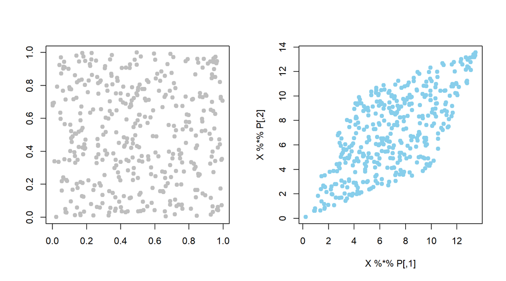

```r
par(mfrow = c(1, 2))
plot(X, xlab = "", ylab = "", pch = 19, col = "gray")
plot(X %*% P, col = "skyblue", pch = 19)
```

## 역행렬

정사각행렬 $A$에 대해 $A A^{-1} = I = A^{-1}A$를 만족하는 행렬 $A^{-1}$를 $A$의 **역행렬(inverse matrix)**이라 한다. R 함수 `solve()`를 사용해 구할 수 있다. 다음은 앞에서 생성한 예제 행렬 $X$를 이용해 정사각행렬 $A = X^\top X$을 만든 후 $A$의 역행렬을 구하는 R코드이다.

```r
A <- t(X) %*% X
A.inv <- solve(A)
A.inv
```

```
##             [,1]        [,2]
## [1,]  0.01719930 -0.01255557
## [2,] -0.01255557  0.01655823
```

이 행렬이 역행렬로서의 성질을 만족하는 지 확인해보자.

```r
A %*% A.inv
```

```
##              [,1] [,2]
## [1,] 1.000000e+00    0
## [2,] 4.440892e-16    1
```

```r
A.inv %*% A
```

```
##              [,1]         [,2]
## [1,] 1.000000e+00 2.220446e-16
## [2,] 2.220446e-16 1.000000e+00
```

```r
round(A %*% A.inv, 12)
```

```
##      [,1] [,2]
## [1,]    1    0
## [2,]    0    1
```

```r
round(A.inv %*% A, 12)
```

```
##      [,1] [,2]
## [1,]    1    0
## [2,]    0    1
```

실은 `solve()` 함수는 선형연립방정식의 해를 구하는데 사용되는 범용 함수이다. 선형연립방정식
$$\begin{eqnarray*}
x_1 + 2x_2 + 3x_3 &=& 5 \\
2x_1 - 5x_2 - x_3 &=& 7 \\
x_2 - x_3 &=& 0
\end{eqnarray*}$$
을 만족하는 $x_1$, $x_2$, $x_3$을 구하는 문제를 생각해보자. 이 선형연립방정식을 행렬-벡터 기호를 사용해 $A\boldsymbol{x} = \boldsymbol{b}$의 형태로 나타내면 다음과 같다.
$$\left[\begin{array}{ccc}1 & 2 & 3 \\ 2 & -5 & -1 \\ 0
& 1 & -1 \end{array}\right] \left[\begin{array}{c}x_1 \\ x_2 \\
x_3 \end{array}\right] = \left[\begin{array}{c}5 \\ 7 \\ 0
\end{array}\right]$$
따라서 행렬 $A$의 역행렬을 양변에 곱하면 연립방정식의 해를 $\boldsymbol{x} = A^{-1}\boldsymbol{b}$와 같이 구할 수 있다. 다음은 이를 R 함수 `solve()`를 사용해 풀어낸 예제 코드이다.

```r
Amat <- matrix(c(1,  2,  3,
                 2, -5, -1,
                 0,  1, -1),
               ncol = 3, byrow = TRUE)
bvec <- c(5, 7, 0)
x <- solve(Amat, bvec)
x
```

```
## [1] 4.0625 0.1875 0.1875
```

```r
Amat %*% x   # should be equal to bvec
```

```
##      [,1]
## [1,]    5
## [2,]    7
## [3,]    0
```

## 행렬식

**행렬식(determinant)**은 정사각행렬에 실수값(스칼라)를 대응시키는 함수의 하나로서 다음과 같은 방식으로 정의된다. 행렬 $A$가 $2\times 2$ 행렬일 때
$${\sf det}(A) \equiv |A| = \left|\begin{array}{cc}
a_{11} & a_{12} \\
a_{21} & a_{22}
\end{array}\right|
= a_{11}a_{22} - a_{12}a_{21}$$
와 같이 계산한다. 이를 확장해 $n\times n$ 행렬 $A$는 소위 minor행렬의 행렬식을 이용해 다음과 같이 계산한다.
$$\begin{eqnarray*}
|A| &=& \left|\begin{array}{cccc}
a_{11} & a_{12} & \cdots & a_{1n} \\
a_{21} & a_{22} & \cdots & a_{2n} \\
\vdots & \vdots & \ddots & \vdots \\
a_{n1} & a_{n2} & \cdots & a_{nn}
\end{array}\right|\\
&=& a_{11}\left|\begin{array}{cccc}
a_{22} & a_{23} & \cdots & a_{2n} \\
\vdots & \ddots & \vdots \\
a_{n2} & a_{n3} & \cdots & a_{nn}
\end{array}\right| \\
& & - a_{12} \left|\begin{array}{cccc}
a_{21} & a_{23} & \cdots & a_{2n} \\
\vdots & \vdots & \ddots & \vdots \\
a_{n1} & a_{n3} & \cdots & a_{nn}
\end{array}\right| \\
& & + \cdots \,
\pm\, a_{1n} \left|\begin{array}{cccc}
a_{21} & a_{22} & \cdots & a_{2,n-1} \\
\vdots & \vdots & \ddots & \vdots \\
a_{n1} & a_{n2} & \cdots & a_{n,n-1}
\end{array}\right|
\end{eqnarray*}$$

행렬식을 계산해주는 R 함수는 `det()`이다. 이 함수를 이용해 앞 절의 예제에서 만들었던 정사각행렬 $A = X^\top X$의 행렬식 값을 구해보자.

```r
det(A)
```

```
## [1] 7864.875
```

**행렬식의 의미:**

- $n \times n$ 행렬 $A$는 $\mathbb{R}^n$ 공간에서의 **일차변환(linear map)**을 정의(예: $T_A(x) = Ax$. 이는 벡터 $x$를 다른 벡터로 보내는 선형 사상)
- 행렬식 $\det(A)$는 **그 변환이 공간을 어떻게 바꾸는지 요약**하는 값
  1. 부피 변화율
     - $\mathbb{R}^n$위의 도형을 $n\times n$ 행렬 $A$로 정의되는 변환으로 보낼 때 **그 도형의 부피를 얼마나 확대 또는 축소하는지**가 바로 $|\det(A)|$
     - 예시:
       $$A = \begin{bmatrix}2 & 0 \\ 0 & 3 \end{bmatrix}$$
       이 행렬은 x축 방향으로 2배, y축 방향으로 3배 늘리는 변환. 따라서 이 변환을 적용한 도형의 면적은 $2 \times 3 = 6$배 커지며, 실제로 $\det(A) = 6$.
     - 일반적으로 $\det(A) = 0$이면, 변환 후 공간이 찌그러져 부피가 0이 된다는 뜻(즉, **차원이 축소됨**)
  2. 방향 보존 여부
     - 행렬식의 **부호**는 방향성(orientation)을 나타냄
       - $\det(A) > 0$: 원래의 오른손좌표계/왼손좌표계 방향이 보존됨
       - $\det(A) < 0$: 방향이 뒤집힘

**예졔**

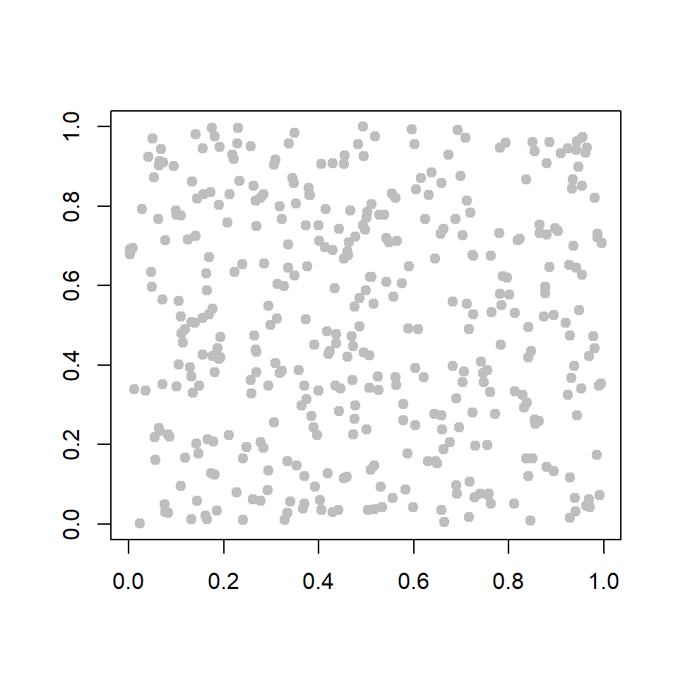

```r
plot(X, xlab = "", ylab = "", pch = 19, col = "gray")
```

```r
print(P <- matrix(c(1, 0.4, 0.4, 1), 2, 2))
```

```
##      [,1] [,2]
## [1,]  1.0  0.4
## [2,]  0.4  1.0
```

```r
print(Q <- matrix(c(1, 0.8, 0.8, 1), 2, 2))
```

```
##      [,1] [,2]
## [1,]  1.0  0.8
## [2,]  0.8  1.0
```

```r
print(R <- matrix(c(1, 0.98, 0.98, 1), 2, 2))
```

```
##      [,1] [,2]
## [1,] 1.00 0.98
## [2,] 0.98 1.00
```

```r
print(S <- matrix(c(0.4, 1, 1, 0.4), 2, 2))
```

```
##      [,1] [,2]
## [1,]  0.4  1.0
## [2,]  1.0  0.4
```

```r
det(P)
```

```
## [1] 0.84
```

```r
det(Q)
```

```
## [1] 0.36
```

```r
det(R)
```

```
## [1] 0.0396
```

```r
det(S)
```

```
## [1] -0.84
```

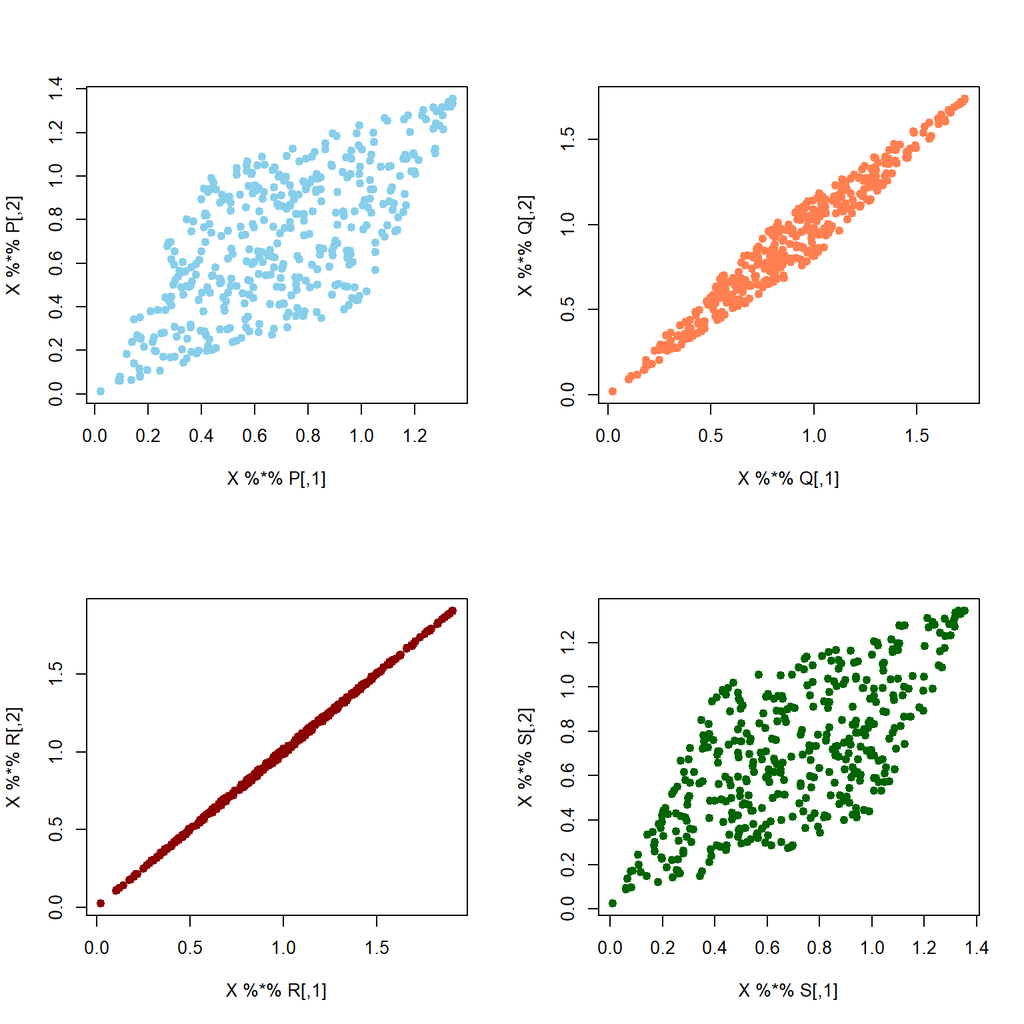

```r
par(mfrow = c(2, 2))
plot(X %*% P, col = "skyblue", pch = 19)
plot(X %*% Q, col = "coral", pch = 19)
plot(X %*% R, col = "darkred", pch = 19)
plot(X %*% S, col = "darkgreen", pch = 19)
```

**행렬식에 관련해 기억해두면 좋은 사실들**

- $|I| = 1$
- $|aA|= a^n|A|$ for $a\in\mathbb{R}$
- $|-A| = (-1)^n|A|$
- $|AB| = |A|\cdot|B|$
- $A$의 역행렬이 존재하면 $|A^{-1}| = 1/|A|$
- $|A^\top| = |A|$
- $|BAB^{-1}| = |B|\cdot|A|\cdot|B^{-1}| = |A|$

## 행렬의 분해

### 상삼각행렬, 하삼각행렬

```r
print(A <- round(A, 2))
```

```
##        [,1]   [,2]
## [1,] 130.23  98.75
## [2,]  98.75 135.27
```

```r
upper.tri(A)
```

```
##       [,1]  [,2]
## [1,] FALSE  TRUE
## [2,] FALSE FALSE
```

```r
lower.tri(A)
```

```
##       [,1]  [,2]
## [1,] FALSE FALSE
## [2,]  TRUE FALSE
```

```r
A[lower.tri(A)] <- 0
A
```

```
##        [,1]   [,2]
## [1,] 130.23  98.75
## [2,]   0.00 135.27
```

### QR 분해

**QR 분해(QR decomposition)**는 정사각행렬 $A$를 $A = QR$과 같이 분해하는 것을 가리킨다. 단, $Q$는 **직교행렬**(역행렬이 전치행렬과 같음: $QQ^\top = I$)이고 $R$은 상삼각행렬이다. R 함수 `qr()`을 이용하면 간단히 QR분해를 실행할 수 있다.

QR 분해는 선형연립방정식 $A\boldsymbol{x} = \boldsymbol{b}$의 해를 안정적으로 구하는 데 매우 유용하다.
$$A\boldsymbol{x} = \boldsymbol{b} \quad \Leftrightarrow \quad
QR\boldsymbol{x} = \boldsymbol{b} \quad \Leftrightarrow \quad
R\boldsymbol{x} = Q^\top \boldsymbol{b}$$
가 성립하는데, 마지막 식의 $R$이 상삼각행렬이기 때문에 순차적으로 $x$값들을 계산할 수 있게 된다. 앞에서 살펴본 예제 연립방정식
$$\begin{eqnarray*}
x_1 + 2x_2 + 3x_3 &=& 5 \\
2x_1 - 5x_2 - x_3 &=& 7 \\
x_2 - x_3 &=& 0
\end{eqnarray*}$$
을 이용해 이해해보자.

```r
Amat
```

```
##      [,1] [,2] [,3]
## [1,]    1    2    3
## [2,]    2   -5   -1
## [3,]    0    1   -1
```

```r
bvec
```

```
## [1] 5 7 0
```

이므로, `Amat`에 대해 QR분해를 실시한다.

```r
A.qr <- qr(Amat)
Q <- qr.Q(A.qr)
R <- qr.R(A.qr)
```

```r
Q
```

```
##            [,1]       [,2]       [,3]
## [1,] -0.4472136  0.8680371 -0.2156655
## [2,] -0.8944272 -0.4340185  0.1078328
## [3,]  0.0000000  0.2411214  0.9704950
```

```r
R
```

```
##           [,1]     [,2]       [,3]
## [1,] -2.236068 3.577709 -0.4472136
## [2,]  0.000000 4.147288  2.7970084
## [3,]  0.000000 0.000000 -1.7253244
```

```r
t(Q) %*% bvec
```

```
##            [,1]
## [1,] -8.4970583
## [2,]  1.3020556
## [3,] -0.3234983
```

따라서 이 연립방정식의 해는
$$\left[\begin{array}{rrr}
-2.236068 & 3.577709 & -0.4472136 \\
0.000000 & 4.147288 & 2.7970084 \\
0.000000 & 0.000000 & -1.7253244
\end{array}\right]
\left[\begin{array}{c}
x_1 \\ x_2 \\ x_3
\end{array}\right]
= \left[\begin{array}{r}
-8.4970583 \\ 1.3020556 \\ -0.3234983
\end{array}\right]$$
을 풀어 구할 수 있다. 우선 위 방정식의 좌변에서 $R$ 행렬의 맨 아래 행과 $\boldsymbol{x}$ 사이의 행렬곱과 우변의 마지막 성분 사이의 등식을 이용하면 $x_3$의 값을 쉽게 구할 수 있고, 나머지 해도 순차적으로 구할 수 있음을 알 수 있다.

### 고윳값 분해

정방행렬 $A$에 대해 $A\boldsymbol{p} = \lambda \boldsymbol{p}$을 만족하는 벡터 $\boldsymbol{p}(\neq {\mathbf 0})$를 **고유벡터(eigen vector)**라 한다. 단, $\boldsymbol{p}$의 길이는 $1$이 되도록 한다. 즉, $\boldsymbol{p}^\top \boldsymbol{p} = 1$ 이다. 그리고, 스칼라 상수 $\lambda$를 행렬 $A$의 **고윳값(eigen value)**이라 하는데 다항방정식 $\det(A - \lambda I) = 0$의 해이다.

고윳값 분해에 관련해 유용한 사실들을 소개하면 다음과 같다.

- 서로 다른 고윳값에 대응되는 고유벡터는 서로 직교한다. 즉, $j\neq k$이면 $\boldsymbol{p}_j^\top \boldsymbol{p}_k = 0$이다. 따라서 $P^\top P = PP^\top = I$ 이다.
- $A$의 대각원소의 합(trace)은 고윳값의 합과 같다.
  $${\sf tr}(A) = {\sf tr}(P\Lambda P^\top) = {\sf tr}(\Lambda P^\top P) =
  {\sf tr}(\Lambda) = \sum_{j=1}^d \lambda_j$$
- 행렬 $A$가 양정치(positive definite) $\Leftrightarrow$ 고윳값이 모두 양수(positive)
- 행렬 $A$가 양반정치(positive semi-definite) $\Leftrightarrow$ 고윳값이 모두 음이 아님(nonnegative)
- 역행렬을 구하는 데 유용하다. $P^{-1} = P^\top$이므로
  $$A^{-1} = P \Lambda^{-1}P^\top$$
  가 된다.

#### Example: Eigen-decomposition

다음은 $N(0,1)$에서 생성한 난수 500개로 구성된 행렬 $D_{(100\times 5)}$의 분산공분산행렬 $A$에 대해 고윳값 분해를 실시한 예제이다. R의 내장함수 `eigen()`을 이용하면 된다.

```r
set.seed(0)
N <- 100
d <- 5
D <- matrix(rnorm(N*d), N, d)
head(D)
```

```
##            [,1]       [,2]       [,3]       [,4]       [,5]
## [1,]  1.2629543  0.7818592 -1.0457177 -0.1244350 -0.3900096
## [2,] -0.3262334 -0.7767766 -0.8962113  1.4667446 -1.8192222
## [3,]  1.3297993 -0.6159899  1.2693872  0.6739287  0.6591807
## [4,]  1.2724293  0.0465803  0.5938409  1.9564253  0.4596217
## [5,]  0.4146414 -1.1303858  0.7756343 -0.2690410  1.6166263
## [6,] -1.5399500  0.5767188  1.5573704 -1.2445515 -1.8561905
```

```r
A <- cov(D)
print(A)
```

```
##            [,1]         [,2]         [,3]         [,4]        [,5]
## [1,] 0.77907136  0.108131038  0.060406951  0.128325842  0.11391580
## [2,] 0.10813104  0.932168216 -0.009251608 -0.028288798 -0.04610195
## [3,] 0.06040695 -0.009251608  1.106967316  0.003883494  0.04508903
## [4,] 0.12832584 -0.028288798  0.003883494  0.894277288  0.11976022
## [5,] 0.11391580 -0.046101952  0.045089027  0.119760222  1.21420202
```

```r
eig <- eigen(A)
eig
```

```
## eigen() decomposition
## $values
## [1] 1.3159626 1.0966904 0.9906025 0.8788875 0.6445433
##
## $vectors
##             [,1]        [,2]       [,3]         [,4]        [,5]
## [1,] -0.28118236 -0.06434096  0.4476724  0.208808120  0.82023491
## [2,]  0.05473611 -0.08583592  0.8574502 -0.344747866 -0.36819038
## [3,] -0.27433672 -0.94847632 -0.1218330 -0.002116955 -0.10141144
## [4,] -0.33454597  0.11560315  0.1839556  0.818077506 -0.41427580
## [5,] -0.85484431  0.27481089 -0.1252420 -0.410235043 -0.09870068
```

위에서 생성했던 $A$와 고윳값 분해 결과를 비교해보라.

```r
lambda <- eig$values
P <- eig$vectors
print(P %*% diag(lambda) %*% t(P))
```

```
##            [,1]         [,2]         [,3]         [,4]        [,5]
## [1,] 0.77907136  0.108131038  0.060406951  0.128325842  0.11391580
## [2,] 0.10813104  0.932168216 -0.009251608 -0.028288798 -0.04610195
## [3,] 0.06040695 -0.009251608  1.106967316  0.003883494  0.04508903
## [4,] 0.12832584 -0.028288798  0.003883494  0.894277288  0.11976022
## [5,] 0.11391580 -0.046101952  0.045089027  0.119760222  1.21420202
```

$\Box$

#### Example: Whitening & coloring

분산공분산행렬 $\boldsymbol\Sigma$에 대해 $\boldsymbol\Sigma = P \Lambda P^\top$와 같이 고윳값 분해를 실시하면
$$\boldsymbol\Sigma^{1/2} = P \Lambda^{1/2}P^\top,\quad
\boldsymbol\Sigma^{-1/2} = P \Lambda^{-1/2}P^\top.$$
단, $\Lambda^{1/2} = {\sf diag}(\lambda_1^{1/2},...,\lambda_d^{1/2})$, $\Lambda^{-1/2} = {\sf diag}(\lambda_1^{-1/2},...,\lambda_d^{-1/2})$이다.

($\because$)
$$\begin{eqnarray*}
& & \boldsymbol\Sigma^{1/2}\boldsymbol\Sigma^{1/2}
= P \Lambda^{1/2}P^\top \, P\Lambda^{1/2}P^\top
= P \Lambda^{1/2} {\boldsymbol{I}} \Lambda^{1/2}P^\top
= P \Lambda P^\top = \boldsymbol\Sigma, \\
& & \boldsymbol\Sigma^{-1/2}\boldsymbol\Sigma^{-1/2}
= P \Lambda^{-1/2}P^\top \, P\Lambda^{-1/2}P^\top
= P \Lambda^{-1/2} {\boldsymbol{I}} \Lambda^{-1/2}P^\top
= P \Lambda^{-1} P^\top = \boldsymbol\Sigma^{-1}
\quad \Box
\end{eqnarray*}$$

- **Whitening**: $\boldsymbol\Sigma_{\boldsymbol{X}} = {\sf Cov}({\boldsymbol{X}})$라 하면,
  - ${\boldsymbol{Z}} = \boldsymbol\Sigma_{\boldsymbol{X}}^{-1/2}{\boldsymbol{X}}$와 같이 변환하면
    $${\sf Cov}({\boldsymbol{Z}}) =
    \boldsymbol\Sigma_{\boldsymbol{X}}^{-1/2}\,\boldsymbol\Sigma_{\boldsymbol{X}}
    \,\boldsymbol\Sigma_{\boldsymbol{X}}^{-1/2}={\boldsymbol{I}}$$
    가 됨
- **Coloring**: ${\sf Cov}({\boldsymbol{X}}) = \boldsymbol\Sigma_{\boldsymbol{X}}$, ${\sf Cov}({\boldsymbol{Y}}) = \boldsymbol\Sigma_{\boldsymbol{Y}}$ 일 때,
  1. ${\boldsymbol{X}}$를 whitening: ${\boldsymbol{Z}} = \boldsymbol\Sigma_{\boldsymbol{X}}^{-1/2}{\boldsymbol{X}}$
  2. ${\boldsymbol{Z}}$에 $\boldsymbol{Y}$의 공분산 구조를 coloring: $\tilde{\boldsymbol{X}} = \boldsymbol\Sigma_{\boldsymbol{Y}}^{1/2}{\boldsymbol{Z}} = \boldsymbol\Sigma_{\boldsymbol{Y}}^{1/2}\boldsymbol\Sigma_{\boldsymbol{X}}^{-1/2}{\boldsymbol{X}}$.
  3. $\tilde{\boldsymbol{X}}$는 ${\boldsymbol{Y}}$와 동일한 공분산 행렬을 가짐. 즉,
     $${\sf Cov}(\tilde{\boldsymbol{X}}) =
     \boldsymbol\Sigma_{\boldsymbol{Y}}^{1/2} {\sf
     Cov}(\boldsymbol{Z})\boldsymbol\Sigma_{\boldsymbol{Y}}^{1/2} =
     \boldsymbol\Sigma_{\boldsymbol{Y}}.$$

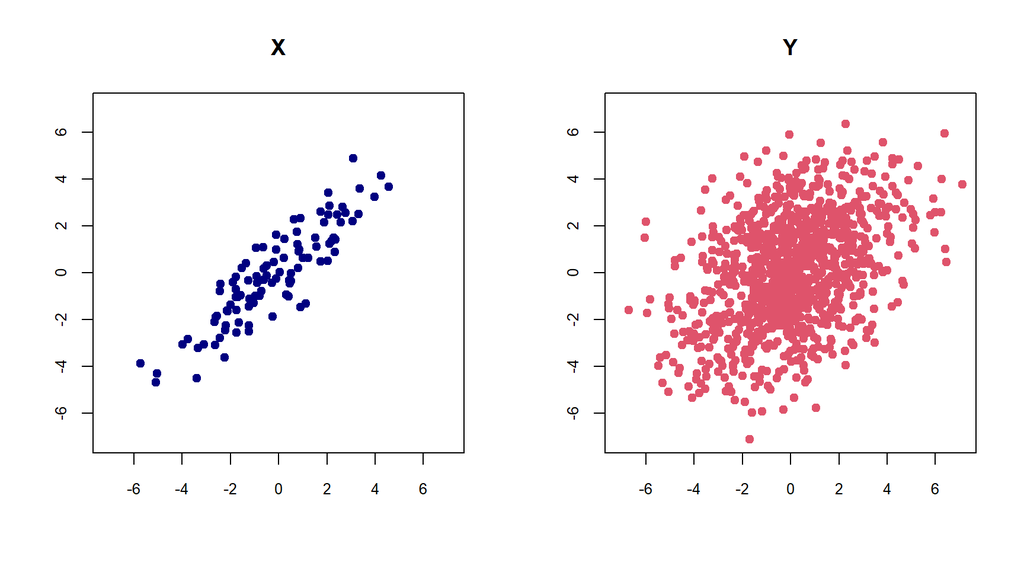

  ```r
  library(mvtnorm)

  N.1 <- 100
  N.2 <- 1000
  d <- 2
  Sigma.1 <- matrix(c(5, 4.5,
                      4.5, 5), byrow = TRUE, ncol = d)
  Sigma.2 <- matrix(c(5, 2,
                      2, 5), byrow = TRUE, ncol = d)

  Xmat <- rmvnorm(N.1, sigma = Sigma.1)
  Ymat <- rmvnorm(N.2, sigma = Sigma.2)

  lbub <- range(rbind(Xmat, Ymat))

  par(mfrow = c(1, 2))
  plot(Xmat, pch = 19, xlab = "", ylab = "", col = "navy",
       xlim = lbub, ylim = lbub, main = "X", cex.axis = 0.8)
  plot(Ymat, pch = 19, xlab = "", ylab = "", col = 2,
       xlim = lbub, ylim = lbub, main = "Y", cex.axis = 0.8)
  ```

  ```r
  S.1 <- cov(Xmat)
  S.1
  ```

  ```
  ##          [,1]     [,2]
  ## [1,] 4.568211 3.873378
  ## [2,] 3.873378 4.154028
  ```

  ```r
  eig <- eigen(S.1)
  lambda <- eig$values
  P <- eig$vectors
  W <- P %*% diag(1/lambda^0.5) %*% t(P)
  Zmat <- Xmat %*% W
  S.Z <- cov(Zmat) # round(cov(Zmat), 6)
  S.Z
  ```

  ```
  ##               [,1]          [,2]
  ## [1,]  1.000000e+00 -3.130218e-16
  ## [2,] -3.130218e-16  1.000000e+00
  ```

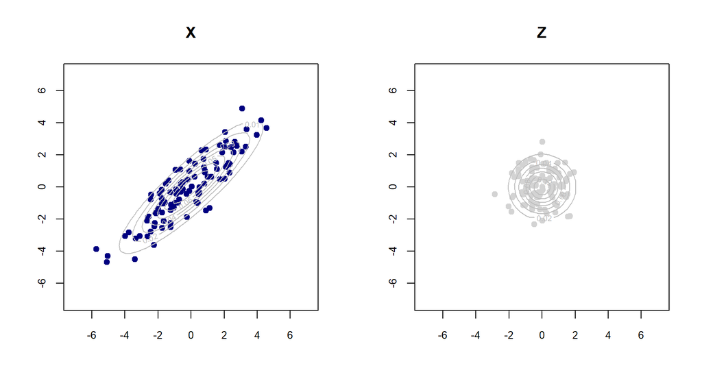

  ```r
  f <- function(x, y, mu, sigma)
  {
    library(mvtnorm)
    dmvnorm(cbind(x, y), mean = mu, sigma = sigma)
  }

  x <- y <- seq(from = lbub[1], to = lbub[2], length.out = 50)

  par(mfrow = c(1, 2))
  plot(Xmat, pch = 19, xlab = "", ylab = "", col = "navy",
       xlim = lbub, ylim = lbub, main = "X", cex.axis = 0.8)
  contour(x, y, outer(x, y, f, mu = c(0, 0), sigma = S.1), add = TRUE, col = "gray")
  plot(Zmat, pch = 19, xlab = "", ylab = "", col = "lightgray",
       xlim = lbub, ylim = lbub, main = "Z", cex.axis = 0.8)
  contour(x, y, outer(x, y, f, mu = c(0, 0), sigma = S.Z), add = TRUE, col = "gray")
  ```

  ```r
  S.2 <- cov(Ymat)
  S.2
  ```

  ```
  ##          [,1]     [,2]
  ## [1,] 4.815442 2.032066
  ## [2,] 2.032066 5.431501
  ```

  ```r
  eig <- eigen(S.2)
  lambda <- eig$values
  P <- eig$vectors
  W <- P %*% diag(lambda^0.5) %*% t(P)
  Y.X <- Zmat %*% W
  cov(Y.X)
  ```

  ```
  ##          [,1]     [,2]
  ## [1,] 4.815442 2.032066
  ## [2,] 2.032066 5.431501
  ```

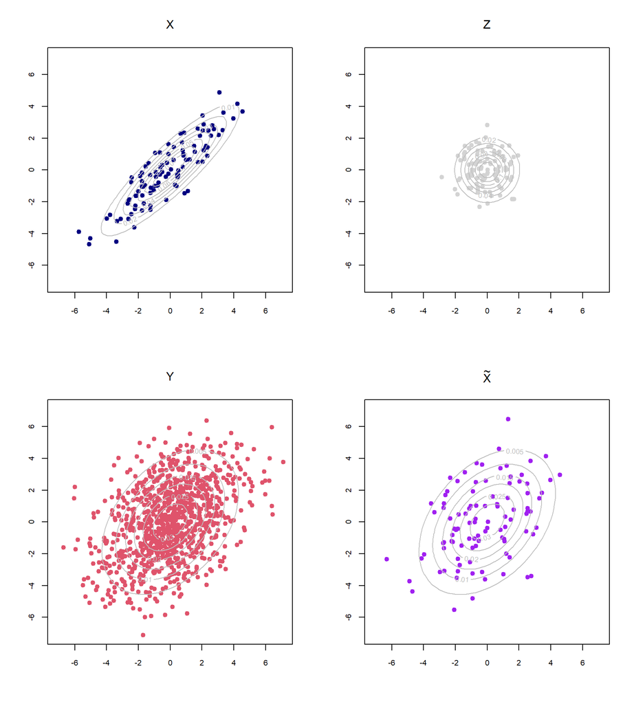

  ```r
  par(mfrow = c(2, 2))
  plot(Xmat, pch = 19, xlab = "", ylab = "", col = "navy",
       xlim = lbub, ylim = lbub, main = expression(X), cex.axis = 0.8)
  contour(x, y, outer(x, y, f, mu = c(0, 0), sigma = S.1), add = TRUE, col = "gray")
  plot(Zmat, pch = 19, xlab = "", ylab = "", col = "lightgray",
       xlim = lbub, ylim = lbub, main = expression(Z), cex.axis = 0.8)
  contour(x, y, outer(x, y, f, mu = c(0, 0), sigma = S.Z), add = TRUE, col = "gray")
  plot(Ymat, pch = 19, xlab = "", ylab = "", col = 2,
       xlim = lbub, ylim = lbub, main = expression(Y), cex.axis = 0.8)
  contour(x, y, outer(x, y, f, mu = c(0, 0), sigma = S.2), add = TRUE, col = "gray")
  plot(Y.X, pch = 19, xlab = "", ylab = "", col = "purple",
       xlim = lbub, ylim = lbub, main = expression(tilde(X)), cex.axis = 0.8)
  contour(x, y, outer(x, y, f, mu = c(0, 0), sigma = S.2), add = TRUE, col = "gray")
  ```

  $\Box$

# 수치 미분

## 미분

매끈한 함수 $f$의 **미분(derivative)**은 다음과 같이 변화율의 극한으로 정의된다.
$$\frac{d}{dx} f(x) = f'(x) = \lim_{h\rightarrow 0} \frac{f(x+h) -
f(x)}{h}$$
따라서, $h\approx 0$에 대해 다음의 근사식이 성립한다.
$$f'(x) \approx \frac{f(x+h) - f(x)}{h}$$
보다 정밀한 근사를 원한다면
$$f'(x) \approx \frac{f(x+h) - f(x-h)}{2h}$$
와 같은 트릭을 쓰면 된다. 실은 이 근사 방법은
$$\frac{f(x+h) - f(x-h)}{2h}
= \frac{\frac{f(x+h) - f(x)}{h} + \frac{f(x) - f(x-h)}{h}}{2}$$
에 의한 것으로 이해할 수 있다.

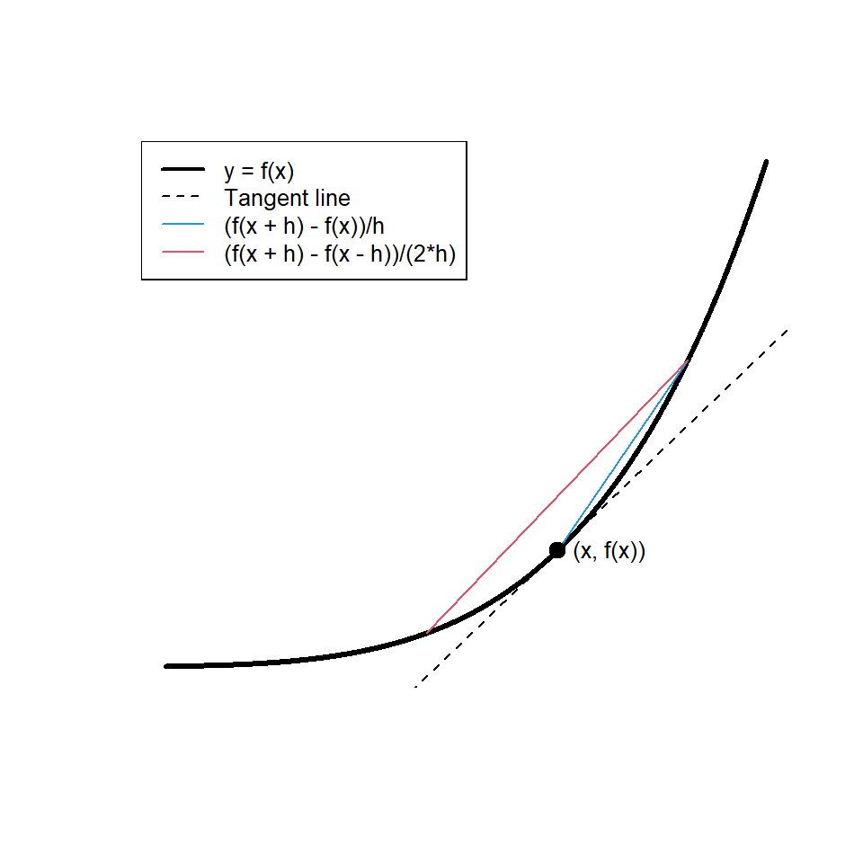

다음은 $f(x) = \exp(-x)$에 대해 $x=1$에서의 미분계수를 구하는 예이다. 실제 도함수는 $f'(x) = -\exp(-x)$이므로 $x=1$에서의 미분계수는 $f'(1) = -e^{-1}\approx -0.367879$이다.

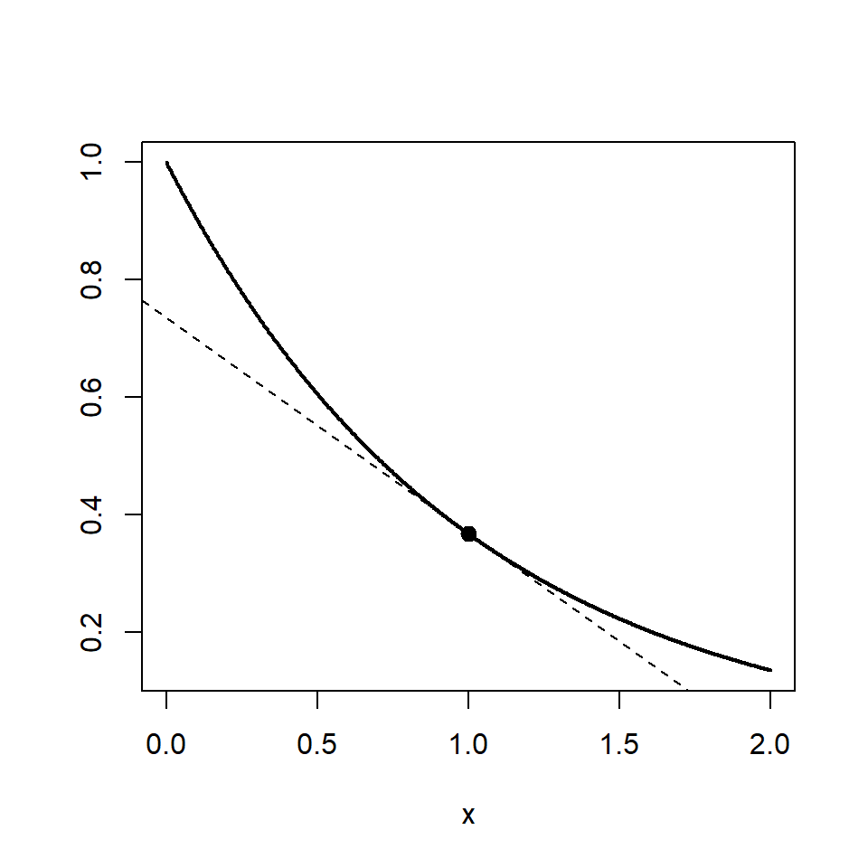

```r
round(-exp(-1), 6)  # 실제 미분계수
```

```
## [1] -0.367879
```

우선 근사식 $f'(x) \approx \frac{f(x+h) - f(x)}{h}$을 적용해보자.

```r
f <- function(x) exp(-x)
print(h <- 2^(-2*(0:10)))
```

```
##  [1] 1.000000e+00 2.500000e-01 6.250000e-02 1.562500e-02 3.906250e-03
##  [6] 9.765625e-04 2.441406e-04 6.103516e-05 1.525879e-05 3.814697e-06
## [11] 9.536743e-07
```

```r
x <- 1
round(rbind(h, (f(x + h) - f(x))/h), 6)
```

```
##        [,1]      [,2]      [,3]      [,4]      [,5]      [,6]      [,7]
## h  1.000000  0.250000  0.062500  0.015625  0.003906  0.000977  0.000244
##   -0.232544 -0.325499 -0.356619 -0.365020 -0.367162 -0.367700 -0.367835
##        [,8]      [,9]     [,10]     [,11]
## h  0.000061  0.000015  0.000004  0.000001
##   -0.367868 -0.367877 -0.367879 -0.367879
```

$h$를 순차적으로 줄여가면서 미분계수의 근사값을 확인해보면 대략 10번째 쯤에서 수렴한 것을 확인할 수 있다. 이번에는 근사식 $f'(x) \approx \frac{f(x+h) - f(x-h)}{2h}$을 적용해보자.

```r
round(rbind(h, (f(x + h) - f(x - h))/(2*h)), 6) # better
```

```
##        [,1]      [,2]      [,3]      [,4]      [,5]      [,6]      [,7]
## h  1.000000  0.250000  0.062500  0.015625  0.003906  0.000977  0.000244
##   -0.432332 -0.371724 -0.368119 -0.367894 -0.367880 -0.367879 -0.367879
##        [,8]      [,9]     [,10]     [,11]
## h  0.000061  0.000015  0.000004  0.000001
##   -0.367879 -0.367879 -0.367879 -0.367879
```

이번에는 대략 6번째 반복에서 수렴한 것으로 보인다. 예상한대로 앞의 근사식보다 훨씬 빨리 수렴 기준에 도달했다.

```r
derivative <- function(f, x, tol = 1e-12, tol.h = 5e-10)
{
  h <- 1e-6
  der0 <- (f(x + h) - f(x - h))/(2*h)
  iter <- 0
  while(1) {
    iter <- iter + 1
    h <- 0.25*h
    der1 <- (f(x + h) - f(x - h))/(2*h)
    diff <- max(abs(der1 - der0))
    if (diff < tol | h < tol.h ) {
      ans <- der1
      break
    }
  }

  return(list(deriv = ans, diff = diff, h = h, iter = iter))
}

#f <- function(x) x^3 - x^2
f <- function(x) sin(pi*x)
```

```r
x <- seq(from = 0, to = 6, by = 0.0025)
der <- derivative(f, x)
str(der)
```

```
## List of 4
##  $ deriv: num [1:2401] 3.14 3.14 3.14 3.14 3.14 ...
##  $ diff : num 5.78e-06
##  $ h    : num 2.44e-10
##  $ iter : num 6
```

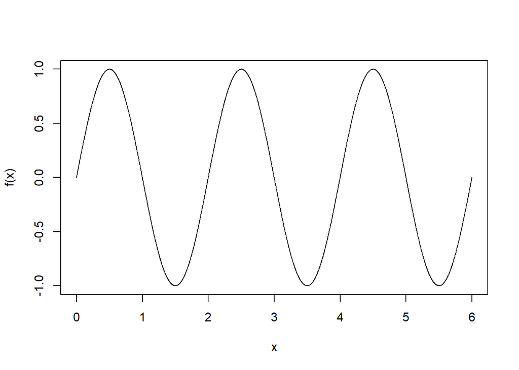

```r
plot(x, f(x), type = 'l')
```

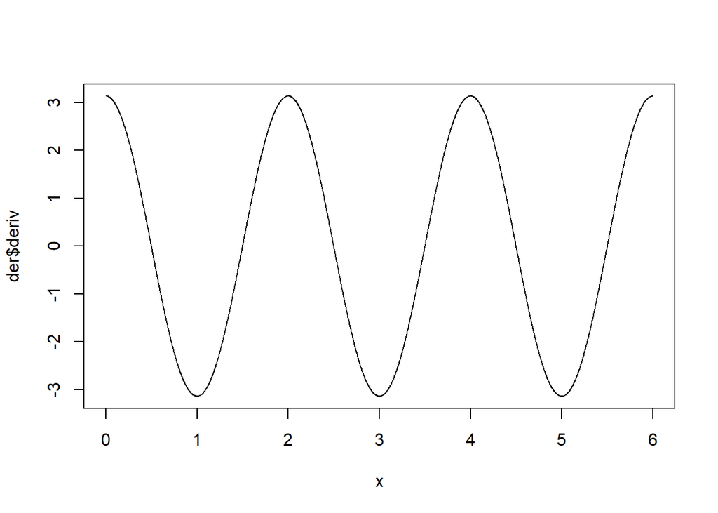

```r
plot(x, der$deriv, type = 'l')
```

## 편미분

다변수 함수 $f({\boldsymbol{x}})$의 미분으로 확장하자면, **편미분(partial derivative)** 즉 특정 변수를 제외한 나머지 변수를 상수로 생각하여 미분하는 것이 쉬운 방법이다.
$$\nabla f({\boldsymbol{x}})
= \left(\frac{\partial f}{\partial
x_i}({\boldsymbol{x}})\right)_{i=1,2,...,d}$$
예를 들어 $f({\boldsymbol{x}}) = f(x_1, x_2) = x_1^2 + x_1x_2 + x_2^2$의 편미분은
$$\frac{\partial f}{\partial x_1}({\boldsymbol{x}}) = 2x_1 + x_2, \quad
\frac{\partial f}{\partial x_2}({\boldsymbol{x}}) = x_1 + 2x_2$$
로 구해진다. 즉,
$$\nabla f({\boldsymbol{x}})
= \left(\begin{array}{c}
2x_1 + x_2 \\ x_1 + 2x_2\end{array}\right)$$
점 $\boldsymbol{x}_0 = (3, 2)^\top$에서의 편미분계수로 구성된 벡터(**그래디언트, gradient**)를 구하면 다음과 같다.
$$\nabla f({\boldsymbol{x}})\Big|_{{\boldsymbol{x}} = \boldsymbol{x}_0}
\equiv \nabla f(\boldsymbol{x}_0)
= \left(\begin{array}{cc}
2\times 3 \,+\, 2 \\
3 \, + \, 2\times 2
\end{array} \right)
= \left(\begin{array}{cc}
8 \\
7
\end{array} \right)$$

다음은 위의 함수 $f$에 대해 편미분계수 $\frac{\partial f}{\partial x_1}\big|_{{\boldsymbol{x}} = (3, 2)}$를 수치적으로 계산하는 예이다. 우선 함수 $f$의 그래프를 살펴보면 아래 그림과 같다.

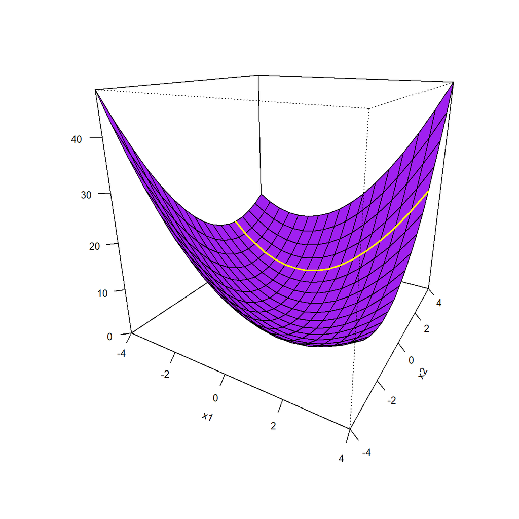

```r
f <- function(x1, x2){
  x1^2 + x1*x2 + x2^2
}

x1 <- seq(from = -4, to = 4, by = 0.5)
x2 <- seq(from = -4, to = 4, by = 0.5)
persp(x1, x2, outer(x1, x2, f),
      col = "purple", ticktype = "detailed", zlab = "", theta = 30, phi = 20,
      cex.axis = 0.8, cex.lab = 0.8) -> res
lines(trans3d(x1, 2, f(x1, 2), res), col = "yellow", lwd = 2)
```

곡면 위에 보이는 노란색 실선은 $x_2 = 2$인 경우의 단면, 즉 $f(x_1, 2) = x_1^2 + 2x_1 + 2^2$의 궤적을 나타낸 것이다. $\frac{\partial f}{\partial x_1}\big|_{{\boldsymbol{x}} = (3, 2)}$은 이 궤적에서 구한 $x_1 = 3$에서의 미분계수가 된다.

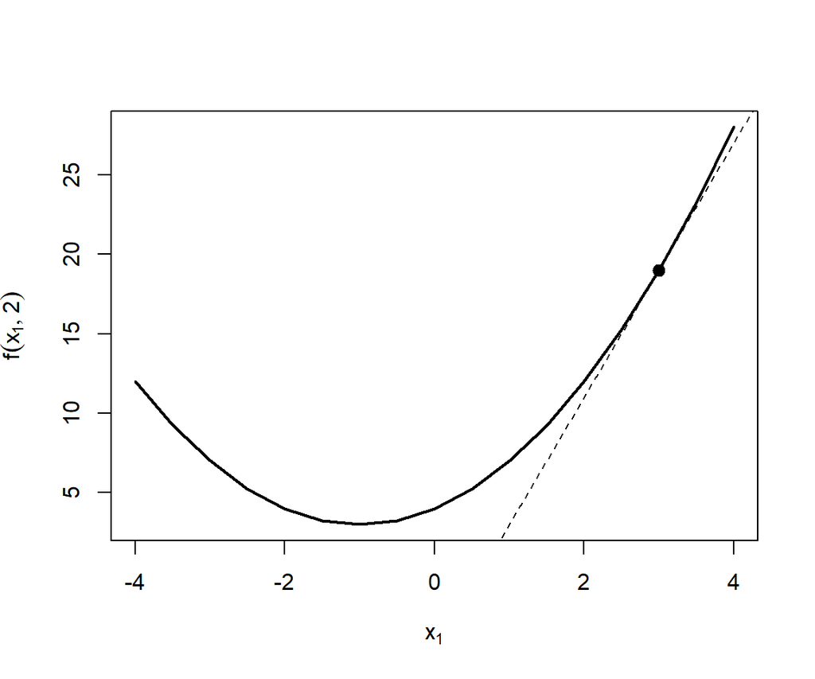

```r
fs <- function(x) f(x, 2)
derivative(fs, 3)
```

```
## $deriv
## [1] 8.000003
##
## $diff
## [1] 2.707168e-06
##
## $h
## [1] 2.441406e-10
##
## $iter
## [1] 6
```

```r
fs <- function(x) f(3, x)
derivative(fs, 2)
```

```
## $deriv
## [1] 6.999995
##
## $diff
## [1] 4.904521e-06
##
## $h
## [1] 2.441406e-10
##
## $iter
## [1] 6
```

# 수치 적분

## 직사각형/사다리꼴 quadrature 방법

정적분 $\int_a^b f(x) dx$를 수치해석적으로 계산하는 방법을 생각해보자. 가장 간단한 방법은 직사각형 구적법으로 근사하는 방법이다.
$$\int_a^b f(x) dx \approx \sum_{i=1}^n f(x_i)\times {\rm \delta}$$
단, $\delta = (b - a)/n$, $x_i = a + (i-1)\delta$, $i=1,2,...,n$ 이다.

이를 좀더 정교화한 것이 사다리꼴 근사이다.

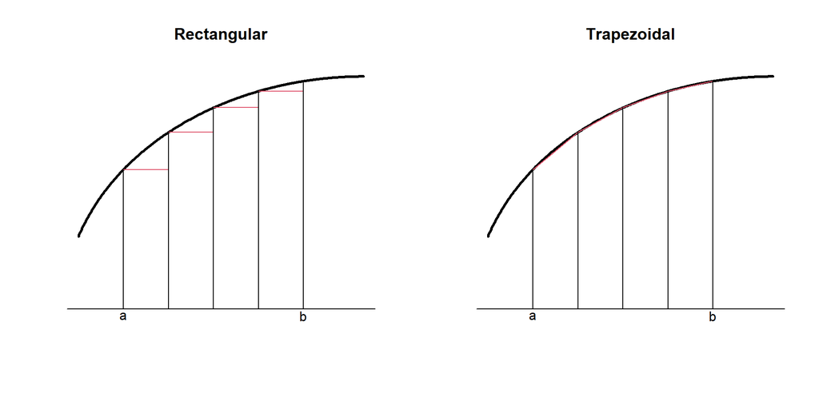

다음은 위 수치 적분 방법들을 사용해 $\int_0^{\pi/2} \sin x \,\,dx$를 계산한 예이다. 실제 적분값은 1이다.

```r
f <- function(x) sin(x)
a <- 0; b <- pi/2; inc <- 2e-6
x <- seq(from = a, to = b, by = inc)
y <- f(x)
n <- length(y)
integ.rect <- sum(y[-n]*inc)
integ.trpz <- sum(y*inc) - 0.5*(y[1] + y[n])*inc
round(c(integ.rect, integ.trpz), 6)
```

```
## [1] 0.999999 1.000000
```

## Gaussian quadrature 방법

함수 $f$가 구간 $[-1, 1]$에서 $(2n-1)$차 이하의 다항식으로 잘 근사될 수 있을 때, 이 구간에서의 정적분을 아래와 같이 근사하는 방법이다.
$$\int_{-1}^1 f(x)\,dx \approx \sum_{i=1}^n w_i f(x_i)$$
$w_i$와 $x_i$의 값은 아래 표와 정리되어 있는 것을 이용하면 된다. 만일 함수 $f$가 $(2n-1)$차 이하의 다항식의 경우에는 위 관계는 등식이 된다.

**Gauss-Legendre:**

| $n$ | $w_i$ | $x_i$ |
| --- | --- | --- |
| 2 | $w_1 = 1$, $w_2 = 1$ | $x_1 = -0.577350269$, $x_2 = +0.577350269$ |
| 3 | $w_1 = 0.5555556$, $w_2 = 0.8888889$, $w_3 = 0.5555556$ | $x_1 = -0.774596669$, $x_2 = 0$, $x_3 = +0.774596669$ |
| 4 | $w_1 = 0.3478548$, $w_2 = 0.6521452$, $w_3 = 0.6521452$, $w_4 = 0.3478548$ | $x_1 = -0.861136312$, $x_2 = -0.339981044$, $x_3 = +0.339981044$, $x_4 = +0.861136312$ |
| 5 | $w_1 = 0.2369269$, $w_2 = 0.4786287$, $w_3 = 0.5688889$, $w_4 = 0.4786287$, $w_5 = 0.2369269$ | $x_1 = -0.906179846$, $x_2 = -0.538469310$, $x_3 = 0$, $x_4 = +0.538469310$, $x_5 = +0.906179846$ |
| 6 | $w_1 = 0.1713245$, $w_2 = 0.3607616$, $w_3 = 0.4679139$, $w_4 = 0.4679139$, $w_5 = 0.3607616$, $w_6 = 0.1713245$ | $x_1 = -0.932469514$, $x_2 = -0.661209386$, $x_3 = -0.238619186$, $x_4 = +0.238619186$, $x_5 = +0.661209386$, $x_6 = +0.932469514$ |

위 표의 숫자들은 다음과 같이 구한 결과물이다. $P_n$을 $n$차 Legendre 다항식이라 할 때, $x_i$는 방정식
$$P_n(x) = 0$$
의 해이고, $w_i$는
$$w_i = \frac{2}{(1-x_i^2)\{P_n'(x_i)\}^2}$$
이다.

등식
$$\int_a^b f(x) \,dx = \frac{b-a}{2} \int_{-1}^1 f\left(\frac{b-a}{2}x +
\frac{b+a}{2}\right)\,dx$$
가 성립하므로 $[-1, 1]$이 아닌 임의의 구간에서의 정적분에 대해서도 가우스구적법을 이용할 수 있다. 위 예제의 sine 함수를 적분하는 문제에 적용해보자.

```r
GaussianQuadratureIntegral <- function(f, lower, upper, n = 5)
{
  if (n == 2) {
    w <- c(1, 1)
    x <- c(-0.577350269, 0.577350269)
  } else if (n == 3) {
    w <- c(0.5555556, 0.8888889, 0.5555556)
    x <- c(-0.774596669, 0, 0.774596669)
  } else if (n == 4) {
    w <- c(0.3478548, 0.6521452, 0.6521452, 0.3478548)
    x <- c(-0.861136312, -0.339981044, 0.339981044, 0.861136312)
  } else if (n == 5) {
    w <- c(0.2369269, 0.4786287, 0.5688889, 0.4786287, 0.2369269)
    x <- c(-0.906179846, -0.538469310, 0, 0.538469310, 0.906179846)
  } else if (n == 6) {
    w <- c(0.1713245, 0.3607616, 0.4679139, 0.4679139, 0.3607616, 0.1713245)
    x <- c(-0.932469514, -0.661209386, -0.238619186, 0.238619186, 0.661209386, 0.932469514)
  } else {
    cat("Check n: 2, 3, ..., 6\n")
    return(NA)
  }
  ans <- 0.5*(upper - lower)*sum(w*f(0.5*((upper - lower)*x + (upper + lower))))
  return(ans)
}
```

```r
GaussianQuadratureIntegral(f, 0, pi/2, n = 2)
```

```
## [1] 0.9984726
```

```r
GaussianQuadratureIntegral(f, 0, pi/2, n = 3)
```

```
## [1] 1.000008
```

```r
GaussianQuadratureIntegral(f, 0, pi/2, n = 4)
```

```
## [1] 1
```

```r
GaussianQuadratureIntegral(f, 0, pi/2, n = 5)
```

```
## [1] 1
```

```r
GaussianQuadratureIntegral(f, 0, pi/2, n = 6)
```

```
## [1] 1
```

`gss` 패키지의 `gauss.quad()` 함수를 이용할 수도 있다.

```r
library(gss)
gauss.quad(size = 5, interval = c(-1, 1))
```

```
## $pt
## [1] -0.9061798 -0.5384693  0.0000000  0.5384693  0.9061798
##
## $wt
## [1] 0.2369269 0.4786287 0.5688889 0.4786287 0.2369269
```

```r
gq <- gauss.quad(size = 5, interval = c(0, pi/2))
sum(gq$wt*f(gq$pt))
```

```
## [1] 1
```

## `integrate()` 함수 이용

`integrate()` 함수는 adaptive quadrature 방법으로 정적분을 계산해준다. Adaptive quadrature 방법을 정리하면 다음과 같다.

1. 구적법으로 계산한 근사값의 오차의 추정치를 계산
2. 미리 설정한 tolerance 보다 크면 적분구간을 반으로 쪼개어 각각의 구간에 대해 구적법을 실시
3. 각 구간에서의 오차 추정치가 tolerance를 만족할 때까지 적분구간을 반으로 쪼개 구적법을 적용하는 것을 반복

다음은 `integrate()` 함수를 이용해 sine 함수의 정적분을 구한 예이다.

```r
integ <- integrate(f = sin, lower = 0, upper = pi/2, abs.tol = 1e-5)
str(integ)
```

```
## List of 5
##  $ value       : num 1
##  $ abs.error   : num 1.11e-14
##  $ subdivisions: int 1
##  $ message     : chr "OK"
##  $ call        : language integrate(f = sin, lower = 0, upper = pi/2, abs.tol = 1e-05)
##  - attr(*, "class")= chr "integrate"
```

```r
print(integ$value)
```

```
## [1] 1
```

무한구간에서의 적분도 계산할 수 있다.

```r
g <- function(x) exp(-x)
integrate(g, lower = 0, upper = Inf)
```

```
## 1 with absolute error < 5.7e-05
```

```r
integrate(dnorm, lower = -Inf, upper = -1.96)
```

```
## 0.0249979 with absolute error < 1.9e-05
```

# 방정식 해 구하기

이 절에서는 방정식 $f(x) = 0$의 수치 해를 구하는 방법을 다룬다.

## Newton-Raphson method

매끈한 함수 $f$에 의해 표현된 방정식 $f(x) = 0$이 주어졌다고 가정하자. $x = x_0$ 근방에서 일차 테일러 전개를 실시하면 다음의 근사식을 얻게 된다.
$$f(x) \approx f(x_0) + f'(x_0) (x - x_0)$$
원래의 방정식 $f(x) = 0$ 을 푸는 대신 위의 근사식을 이용한 방정식 $f(x_0) + f'(x_0) (x - x_0) = 0$을 풀어서 다음과 같은 업데이트 공식을 얻을 수 있다.
$$x \leftarrow x_0 - \frac{f(x_0)}{f'(x_0)}$$
아래 예제는 위 업데이트 알고리즘을 이용해 $x^2 - 1 = 0$의 해를 찾는 예이다. 초기치로 $x_0 = 2$를 사용했다.

```r
f <- function(x) x^2 - 1
f1d <- function(x) 2*x

max.iter <- 1000; tol <- 1e-6
x <- rep(NA, max.iter)    # 추적용

iter <- 1; x0 <- x[iter] <- 2
dd <- f(x0)/f1d(x0)

while ( abs(dd) > tol & iter <= max.iter) {
  iter <- iter + 1
  dd <-  f(x0)/f1d(x0)
  x[iter] <- x0 <- x0 - dd
}
cat(x0, "(# of iterations:", iter, ")\n")
```

```
## 1 (# of iterations: 6 )
```

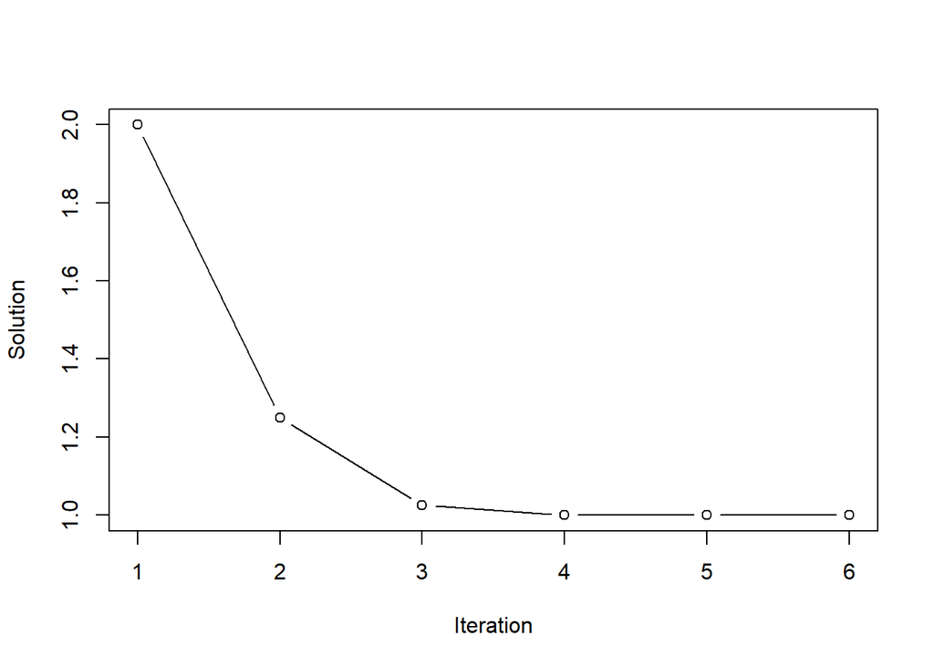

```r
plot(x[1:iter], type = "b", xlab = "Iteration", ylab = "Solution")
```

```r
rbind(x[1:iter], f(x[1:iter]))
```

```
##      [,1]   [,2]     [,3]        [,4]        [,5]         [,6]
## [1,]    2 1.2500 1.025000 1.000304878 1.00000e+00 1.000000e+00
## [2,]    3 0.5625 0.050625 0.000609849 9.29223e-08 2.220446e-15
```

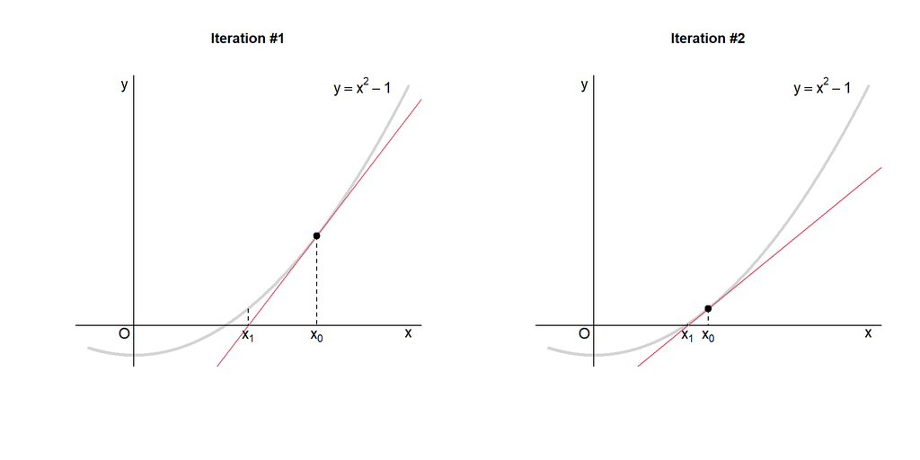

## `uniroot()` 함수

`uniroot()` 함수는 Brent method를 이용한 해를 구해준다. Brent method는 bisection method에 secant method와 inverse quadratic interpolation을 결합한 방법이다. 이 함수를 이용해 $x^2 - 1 = 0$의 해를 구간 $[0, 3]$에서 찾는 예이다.

```r
uniroot(f, lower = 0, upper = 3, tol = 1e-6)
```

```
## $root
## [1] 1
##
## $f.root
## [1] -4.944039e-09
##
## $iter
## [1] 9
##
## $init.it
## [1] NA
##
## $estim.prec
## [1] 5e-07
```

# 최적화

## Newton-Raphson method

아래로 볼록인 함수 $f({\boldsymbol{x}})$의 최소값을 찾는 문제를 생각해보자. $f({\boldsymbol{x}})$가 매끈해서 미분 가능한 경우라면 방정식
$$\nabla f({\boldsymbol{x}}) = {\mathbf 0}$$
의 해를 찾는 문제로 바꿔 생각할 수 있다. 이 방정식의 좌변에 대해 ${\boldsymbol{x}}_0$ 근처에서 1차-테일러 급수 전개를 실시하면
$$\nabla f({\boldsymbol{x}}) \approx \nabla f({\boldsymbol{x}}_0) +
\nabla^2 f({\boldsymbol{x}}_0)({\boldsymbol{x}} - {\boldsymbol{x}}_0)$$
가 되므로
$${\boldsymbol{x}} \,\,\leftarrow\,\, {\boldsymbol{x}}_0 - \left\{\nabla^2
f({\boldsymbol{x}}_0)\right\}^{-1} \nabla f({\boldsymbol{x}}_0)$$
의 업데이트 공식을 얻을 수 있다. 적절한 초기치를 정해 위 업데이트 공식을 수렴 조건을 만족할 때까지 반복 적용해 최적해를 얻는다. 적은 반복횟수로 해를 찾을 수 있지만, 다변수 함수의 최적화 문제에서 이차미분행렬 $\nabla^2 f({\boldsymbol{x}}_0)$의 역행렬을 계산하는 과정에서 어려움이 발생할 수 있다.

아래 예제는 $f(x) = x^4 + 3x^2$의 최소값을 찾는 예이다.

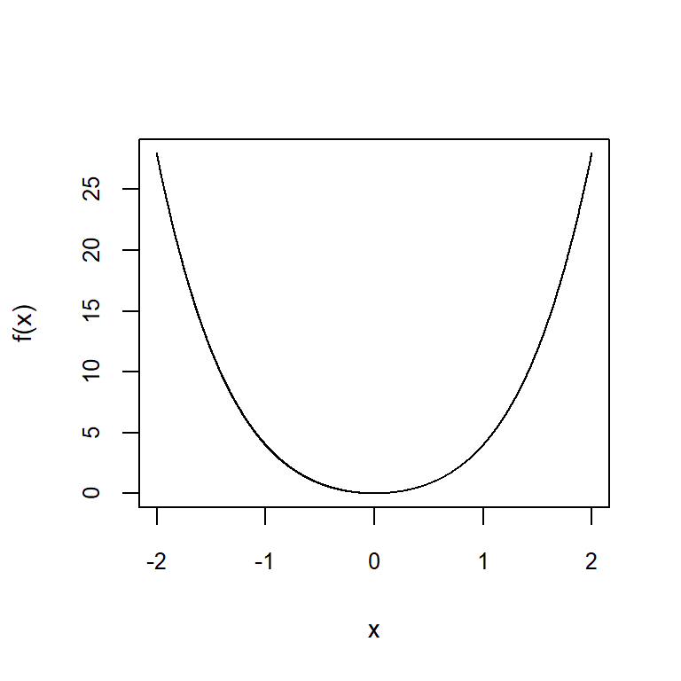

```r
f <- function(x) x^4 + 3*x^2
f1d <- function(x) 4*x^3 + 6*x
f2d <- function(x) 12*x^2 + 6

x <- seq(from = -2, to = 2, by = 0.002)
plot(x, f(x), type = 'l', cex.axis = 0.8, cex.lab = 0.9)
```

```r
dd <- 1000; tol <- 1e-5
iter <- 0; max.iter <- 1000

x0 <- 1
x <- rep(NA, max.iter)

while ( abs(dd) > tol & iter <= max.iter) {
  iter <- iter + 1
  dd <-  f1d(x0)/f2d(x0)
  x[iter] <- x0 <- x0 - dd
}
cat(x0, "(# of iterations:", iter, ")\n")
```

```
## 0 (# of iterations: 5 )
```

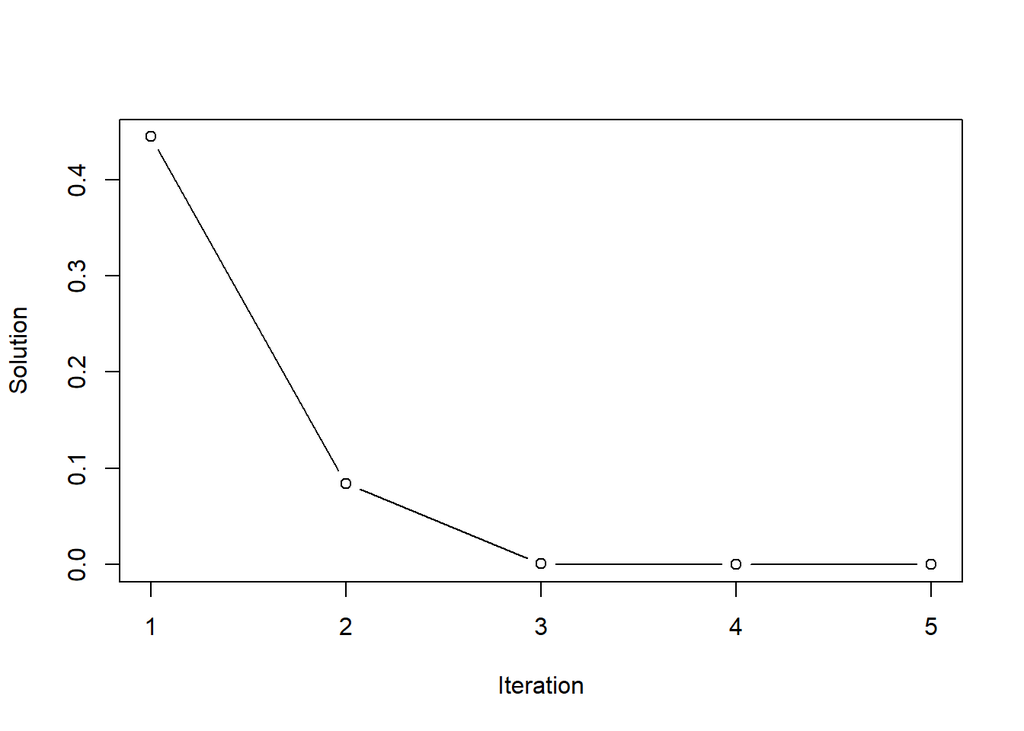

```r
plot(x[1:iter], type = "b", xlab = "Iteration", ylab = "Solution")
abline(h = pi, col = 2, lty = 2)
```

## Gradient method

역시 아래로 볼록인 함수 $f({\boldsymbol{x}})$의 최소값을 찾는 문제에 국한해 생각해보자. 적절한 초기치로부터 출발해 그래디언트가 $\mathbf 0$이 되는 방향으로 해를 업데이트하는 방법이다. Gradient descent 알고리즘이라 한다. 특정 $\boldsymbol{x}_0$에서의 함수 $f$의 그래디언트 $\nabla f({\boldsymbol{x}}_0)$는 함수 $f$의 값이 $\boldsymbol{x}_0$을 기준점으로 놓을 때 가장 빨리 증가하는 방향을 지시하는 벡터이다. 따라서 적절한 양의 상수 $\eta$에 대해
$${\boldsymbol{x}} \leftarrow {\boldsymbol{x}}_0 - \eta\cdot \nabla
f({\boldsymbol{x}}_0)$$
의 업데이트 공식을 사용할 수 있다. 적절한 초기치로 출발해 수렴 조건을 만족할 때까지 위 업데이트 공식을 반복 적용해 최적해를 얻는 방법을 **경사하강법(gradient descent algorithm)**이라 한다. 이차미분에 관련한 이슈가 없어 간편하지만 학습률(learning rate) $\eta$를 잘 설정할 필요가 있다. 학습률을 너무 작게 잡으면 수렴하는데 시간이 오래 걸리게 되고, 반대로 너무 큰 값으로 설정하면 반복 과정에서 최적해를 사이에 두고 계속 진동하면서 수렴하지 않을 가능성이 커진다.

```r
f <- function(x) x^4 + 3*x^2
f1d <- function(x) 4*x^3 + 6*x

eta <- 0.05; dd <- 1000; tol <- 1e-5
iter <- 0; max.iter <- 1000

x0 <- 1
x <- rep(NA, max.iter)

while ( abs(dd) > tol & iter <= max.iter) {
  iter <- iter + 1
  dd <- f1d(x0)
  x[iter] <- x0 <- x0 - eta*dd
}
cat(x0, "(# of iterations:", iter, ")\n")
```

```
## 1.162294e-06 (# of iterations: 37 )
```

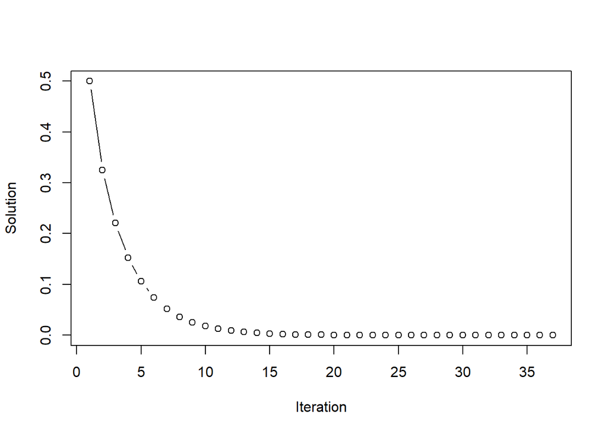

```r
plot(x[1:iter], type = "b", xlab = "Iteration", ylab = "Solution")
```

## `optimise()`, `optim()` 함수 이용

`optimize()`함수는 golden section search 와 successive parabolic interpolation 을 결합한 방식으로 최적해를 찾아준다.

```r
optimize(f, interval = c(-1, 1), maximum = FALSE, tol = 1e-5)
```

```
## $minimum
## [1] 0
##
## $objective
## [1] 0
```

`optim()`함수는 다변수 함수의 최적화 문제를 해결해준다. `method =` 옵션을 통해 Nelder–Mead (default), quasi-Newton, conjugate-gradient, simulated annealing algorithms 등을 선택적으로 사용할 수 있다. Box-constrained optimization을 위한 옵션도 제공한다. 아래 예제는 비선형회귀함수 $y = \beta_0 / (1 + \beta_1 x)$에 대한 최소제곱 추정을 모의실험 데이터에 적용한 예이다. Quasi-Newton 방법을 사용했으며 $\beta$ 값들이 모두 양수가 되어야 한다는 제약 조건을 추가했다.

```r
f <- function(x, y, beta) sum((y - reg(x, beta))^2)
reg <- function(x, beta) beta[1] / (1 + beta[2]*x)

beta <- c(5, 0.5)
n <- 25
x <- runif(n, min = 0, max = 10)
y <- reg(x, beta) + rnorm(n, sd = 0.15)

beta <- optim(c(1, 1), f, x = x, y = y, method = "L-BFGS-B",
              lower = c(0, 0), upper = c(Inf, Inf))$par
print(beta)
```

```
## [1] 5.1092980 0.4954576
```

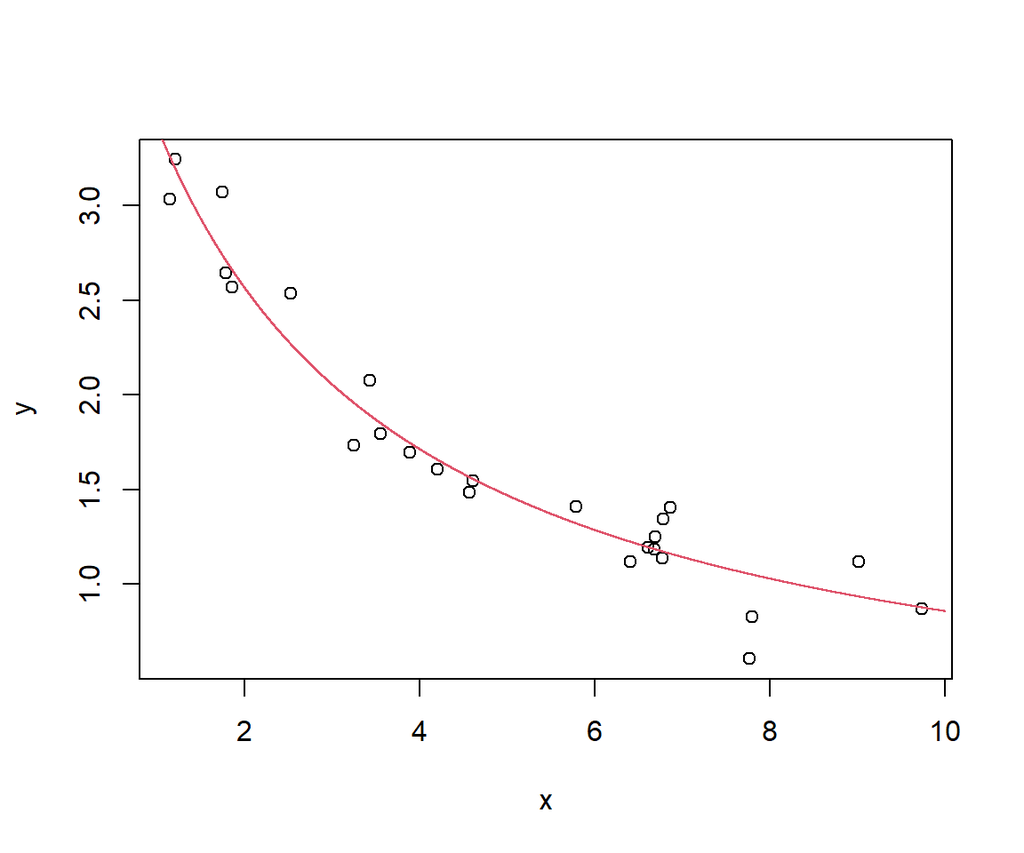

```r
plot(x, y)
x.grid <- seq(from = 0, to = 10, by = 0.001)
lines(x.grid, reg(x.grid, beta), col = 2)
```

## Linear programming

변수들의 선형식에 의한 제약 조건 하에 최적의 선형결합을 찾는 문제를 선형계획법 문제라 한다. 다음은 제약 조건
$$\begin{eqnarray*}
x_1 + 2 x_2 + 3 x_3 &\le& 9 \\
3 x_1 + 2 x_2 + 2 x_3 &\le& 15
\end{eqnarray*}$$
하에 목적함수 $x_1 + 9 x_2 + x_3$를 최대로 하는 $(x_1, x_2, x_3)$를 찾는 예이다.

```r
library(lpSolve)

f.obj <- c(1, 9, 1)
f.con <- matrix(c(1, 2, 3,
                  3, 2, 2),
                nrow = 2, byrow = TRUE)
f.dir <- c("<=", "<=")
f.rhs <- c(9, 15)

res <- lp(direction = "max", objective.in = f.obj,
          const.mat = f.con,
          const.dir = f.dir,
          const.rhs = f.rhs)
res$solution
```

```
## [1] 0.0 4.5 0.0
```

```r
res$objval
```

```
## [1] 40.5
```